# RT analyses

Hannah, 6/22/2017

**Major changes: Updated plots to add CIs**

Uses RT data from Alc Caf for condition 4 (Placebo-placebo) and condition 5 (Control).

“Current” trial will be included if:  
1) Current trial is not the first trial of the block (i.e. trial 1, 101, 201, 301 etc. are not included).  
2) Both current trial and previous trial are correct.  
3) RT is longer than 200 ms and shorter than 2000 ms.

The following subjects were excluded:  
- 92 (wrong number of trials, possibly data collection error)  
- 64 (<50% accuracy rate)

Each subject did 800 trials, with 100 trials in each of 8 blocks.

**Total sample is 50 subjects.**

```
##   compatible Incompatible
##     381.9253     430.3319
```

```
##   compatible Incompatible
##     103.9894     106.2350
```

### 1. Gratton effect at experiment level (grand averages)

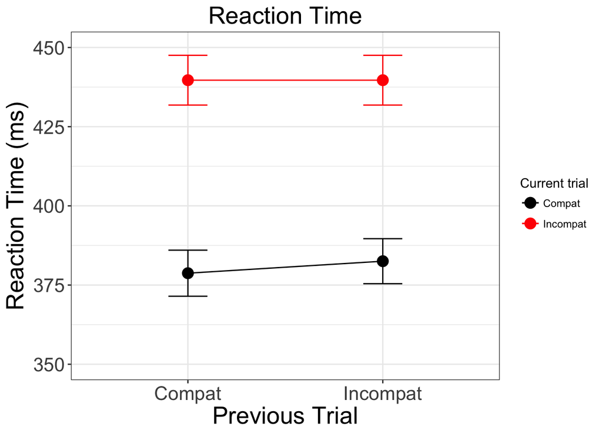

This plot shows marginal means and 95% CI from the (dummy coded) model.  
To look at the fixed effects, current trial type and previous trial type are effect coded.

**Random effects:**

```
##  Groups   Name                 Std.Dev. Corr
##  Subject  (Intercept)          51.9964
##           Current.e             8.5571   0.262
##           Previous.e            1.2051  -0.355  0.649
##           Current.e:Previous.e  2.4818   0.198 -0.347  0.084
##  Residual                      83.1563
```

**Fixed effects:**

```
##                      Estimate Std. Error      df t value Pr(>|t|)
## (Intercept)           409.750      7.367  49.007  55.618    0.000
## Current.e              29.098      1.291  48.656  22.532    0.000
## Previous.e              0.542      0.481 151.369   1.126    0.262
## Current.e:Previous.e   -1.323      0.571  48.988  -2.318    0.025
```

Significant interaction between current trial and previous trial indicates the presence of the Gratton effect.

### 2. Looking at change over course of task

**Slopes and estimates of lines are from the MLM, not fitted with OLS.**

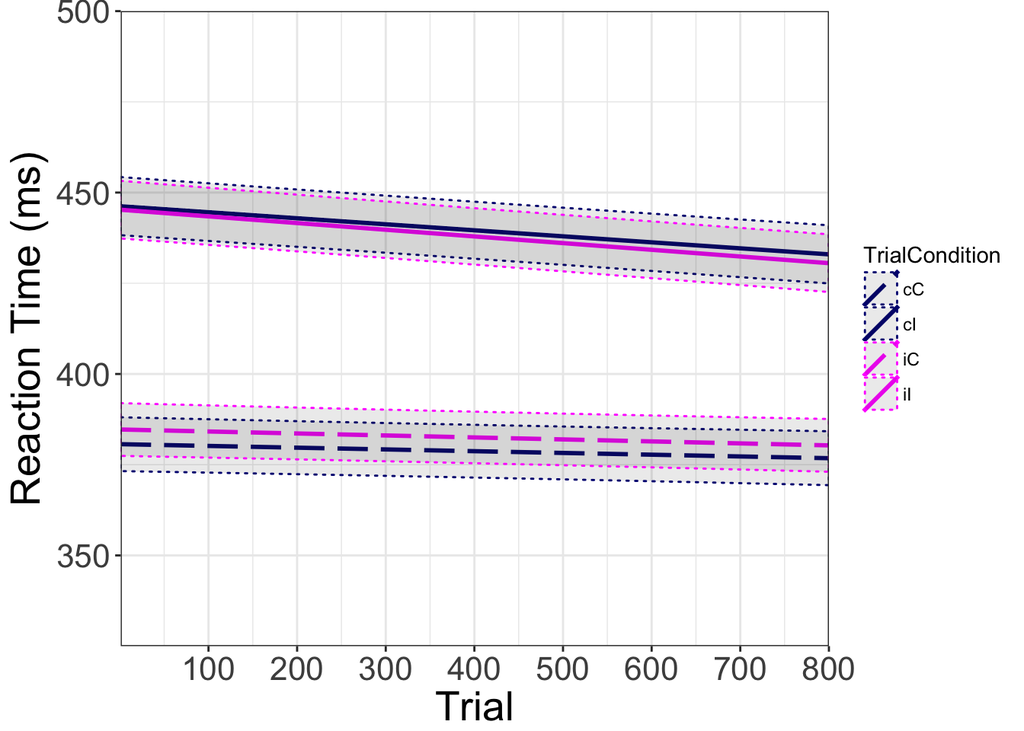

##### Simple slopes

Trial is scaled to range from 0 to 8 (instead of 1 to 800) so that the betas associated with trial are a little bigger (but significance testing is unaffected by linear scaling, so the test statistics and p values will be the same as if we used the unscaled Trial variable).

```
##   Estimate    SE ci95_lower ci95_upper  Current Previous       Color
## 1   -0.483 0.373      -1.23      0.262   Compat   Compat blue dashed
## 2   -0.547 0.388      -1.32      0.230   Compat Incompat  red dashed
## 3   -1.663 0.390      -2.44     -0.882 Incompat   Compat  blue solid
## 4   -1.845 0.406      -2.66     -1.033 Incompat Incompat   red solid
```

#### Beginning of experiment

The intercept, slopes of current and previous trial condition and their interaction are allowed to vary by subject. The same random effects structure is used to probe effects at the beginning, middle, and end of the experiment. *Categorical variables are effect coded.*

To probe effects at the beginning of the experiment, trial is scaled to range from 0 to 8.

**Random effects:**

```
##  Groups   Name                 Std.Dev. Corr
##  Subject  (Intercept)          52.0186
##           Current.e             8.5613   0.264
##           Previous.e            1.2119  -0.356  0.651
##           Current.e:Previous.e  2.4282   0.194 -0.354  0.074
##  Residual                      83.1111
```

**Fixed effects:**

```
##                      Estimate Std. Error       df t value Pr(>|t|)
## (Intercept)           414.184      7.410   50.068  55.894    0.000
## Current.e              31.531      1.502   88.953  20.988    0.000
## Previous.e              0.786      0.906 1788.394   0.868    0.386
## Current.e:Previous.e   -1.204      0.953  393.050  -1.263    0.207
```

```
##                                  Estimate Std. Error       df t value Pr(>|t|)
## Trial.begin                        -1.126      0.195 34282.08  -5.785    0.000
## Current.e:Trial.begin              -0.619      0.195 34256.61  -3.178    0.001
## Previous.e:Trial.begin             -0.063      0.195 34265.69  -0.325    0.745
## Current.e:Previous.e:Trial.begin   -0.033      0.195 34267.97  -0.167    0.867
```

**Marginal means:**  
Error bars represent standard error.

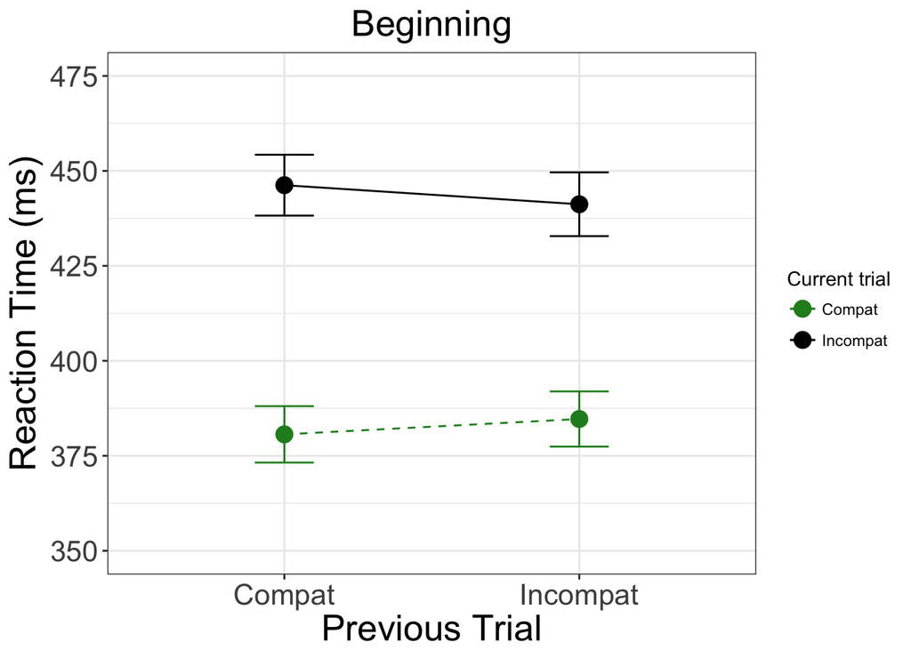

#### Middle of experiment

To probe effects at the middle of the experiment, trial is shifted so that trial ranges from -4 to 4.  
*Just the fixed effects of Current and Previous are shown, the random effects and fixed effects of any Trial interactions will be the same as the first model.*

**Fixed effects:**

```
##                      Estimate Std. Error       df t value Pr(>|t|)
## (Intercept)          409.6793     7.3704  48.9974 55.5844   0.0000
## Current.e             29.0561     1.2919  48.6639 22.4902   0.0000
## Previous.e             0.5323     0.4814 149.1211  1.1058   0.2706
## Current.e:Previous.e  -1.3339     0.5662  49.1513 -2.3557   0.0225
```

**Marginal means:**  
Error bars represent standard error.

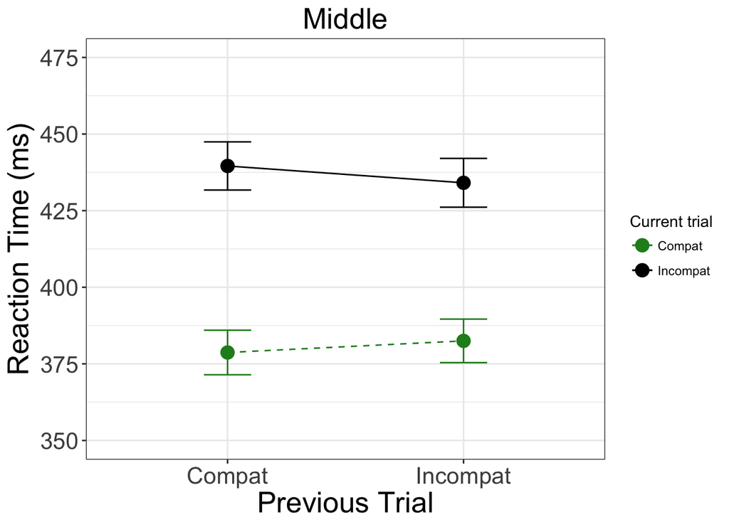

#### End of experiment

To probe the effects at the end of the experiment, trial is shifted so that trial ranges from -8 to 0.  
*Just the fixed effects of Current and Previous are shown, the random effects and fixed effects of any Trial interactions will be the same as the first model.*

**Fixed effects:**

```
##                      Estimate Std. Error        df t value Pr(>|t|)
## (Intercept)          405.1746     7.4127   50.1359 54.6594   0.0000
## Current.e             26.5816     1.5145   91.8590 17.5519   0.0000
## Previous.e             0.2790     0.9254 1932.3865  0.3015   0.7630
## Current.e:Previous.e  -1.4640     0.9723  423.7891 -1.5057   0.1329
```

**Marginal means:**  
Error bars represent standard error.

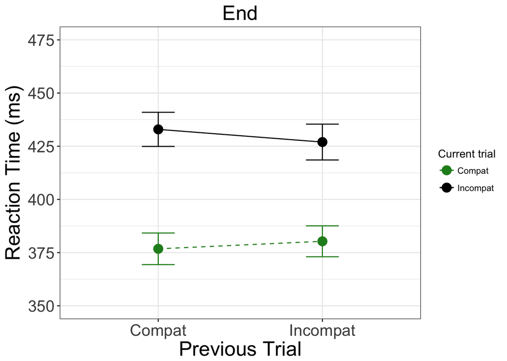